# Movie Analytics with Neo4j: An End-to-End Example

## Grouping and averaging

Grouping works just as well on a value reached through a relationship as on a property of the matched node:

```
//Query: Grouping and Averaging
MATCH (m:Movie)-[:HAS_GENRE]->(g:Genre)
RETURN g.name AS Genre, AVG(m.rating) AS AverageRating
ORDER BY AverageRating DESC
```

Read structurally, this is the same shape as the previous query: `g.name` is the non-aggregated expression and therefore the grouping key, `AVG(m.rating)` is computed within each group, and the results are ordered from the highest-rated genre downwards.

On our graph, however, it returns **no rows at all**, and the reason is different from the empty `SUM` above. There is no `Genre` label and no `HAS_GENRE` relationship type in the Movie graph, as Figure 1 showed: the only labels are `Movie` and `Person`, and the only relationship types are `ACTED_IN`, `DIRECTED`, `PRODUCED`, `WROTE`, `REVIEWED`, and `FOLLOWS`. The `MATCH` pattern therefore matches nothing, and an aggregation over zero rows with a grouping key produces zero rows rather than a row of `null`s.

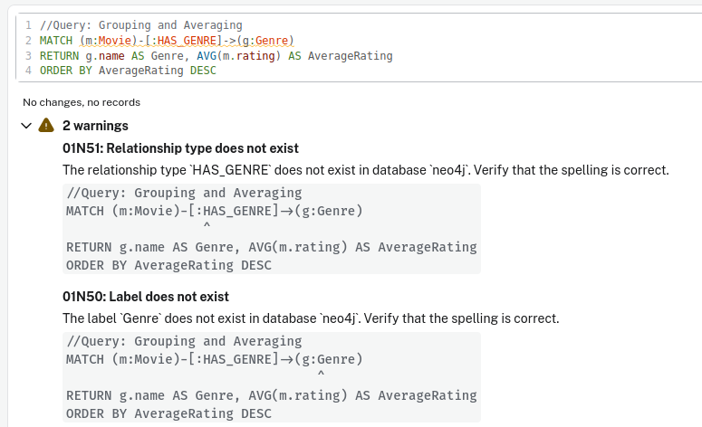

Figure 32: The browser reports “No changes, no records” and raises two warnings rather than an error: `01N51` for the missing `HAS_GENRE` relationship type and `01N50` for the missing `Genre` label, each with a caret marking the offending token in the query.

Figure 32 is worth reading carefully, because the query did not fail. Cypher is schema-optional, so a label or relationship type it has never seen is a legitimate thing to ask for; it simply matches nothing. The database says so as a *warning* rather than an error, which is exactly the same permissiveness that let `m.releaseYear` return `null` in Figure 7. Warnings like these are easy to miss because the result panel above them looks merely empty, and they are the fastest way to diagnose a query that returns nothing for no apparent reason.

**Note**

This is the difference between a failed *pattern* and a missing *property*. `SUM(m.duration)` still had 38 rows to aggregate, they just carried `null` values, so one row came back. `AVG(m.rating)` had no rows to begin with, so nothing came back. When a grouped query returns an empty table, suspect the pattern; when it returns a single row of `null` or `0`, suspect the property name.

The equivalent question that the Movie graph *can* answer uses the ratings the reviewers left on the `REVIEWED` relationship:

```
MATCH (p:Person)-[r:REVIEWED]->(m:Movie)
RETURN m.title AS Movie, AVG(r.rating) AS AverageRating
ORDER BY AverageRating DESC
```

Here `rating` lives on the relationship rather than on either node, which is one of the things a property graph does that a relational schema handles less gracefully. *The Replacements* is the interesting row: it collapses three separate reviews, scored 100, 65, and 62, into a single mean of roughly 75.7.

## Finding the actor with the most movies

The final query combines a traversal, a grouping, a sort, and a limit, which together form one of the most common analytical shapes in Cypher:

```
//Query: Finding the Actor with Most Movies
MATCH (a:Person)-[:ACTED_IN]->(m:Movie)
RETURN a.name AS Actor, COUNT(m) AS NumberOfMovies
ORDER BY NumberOfMovies DESC
LIMIT 1
```

The pattern produces the 172 `ACTED_IN` rows we counted in Section 6.2. `a.name` is the only non-aggregated expression, so those rows are grouped by actor, and `COUNT(m)` gives the number of films each one appeared in. `ORDER BY ... DESC` puts the most prolific first and `LIMIT 1` keeps only the top row, which is Tom Hanks with the 12 films drawn in Figure 18.

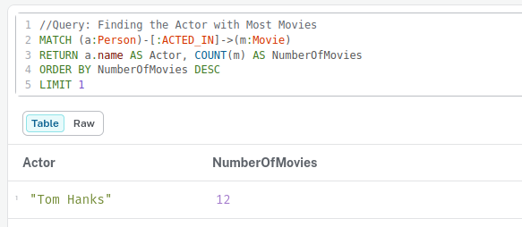

Figure 33: 172 relationships are reduced to 102 grouped rows, sorted, and then cut to one: Tom Hanks with 12 films. The `Actor` column is quoted as a string and `NumberOfMovies` shown as a bare number, the same visual distinction seen throughout.

Figure 33 is the endpoint of the chain this section has been building. The 12 in `NumberOfMovies` is the same 12 that `count(m)` produced in Figure 26, and the same twelve films drawn around Tom Hanks in Figure 18; what has changed is that the query found him rather than being told his name in advance.

`LIMIT` is applied last, after the sort has finished, so the single row returned really is the global maximum rather than the first row that happened to be produced. Raising it to `LIMIT 10` gives the leaderboard instead of the winner, with Keanu Reeves on 7 and Hugo Weaving on 5 beneath Tom Hanks.

**Warning**

`LIMIT 1` hides ties. If two actors were level on 12 films, this query would return one of them arbitrarily and give no hint that the other existed. Ordering by count and returning several rows, or grouping the counts with a second aggregation, is safer whenever ties are plausible.

# MERGE, WITH, and RETURN

Three clauses have appeared repeatedly in the queries above without being examined on their own. `MERGE` is the write clause that matches before it creates, and it is what makes the import script in Section 2 safe to run twice. `WITH` is the pipe that joins one part of a query to the next, which is what allows a write to be followed by a read or an aggregate to be filtered. `RETURN` shapes the final result, and its modifiers `DISTINCT`, `ORDER BY`, and `LIMIT` decide which rows survive and in what order. This section works through each of them in turn.

## Matching before creating with MERGE

`MERGE` is best read as “find this pattern, and if it is not there, create it”:

```
//Query: Using MERGE
MERGE (m:Movie {title: 'The Matrix'})
ON CREATE SET m.released = 1999, m.duration = 136
RETURN m
```

The pattern in braces is both the search key and the blueprint for the new node. Because *The Matrix* already exists in the graph, this query matches the node that the import script wrote and creates nothing; the `ON CREATE SET` clause fires only on the creating branch, so no `duration` property is added and the status bar reports zero writes. Deleting the film first and re-running the query would take the other branch, creating the node and setting both properties in one step.

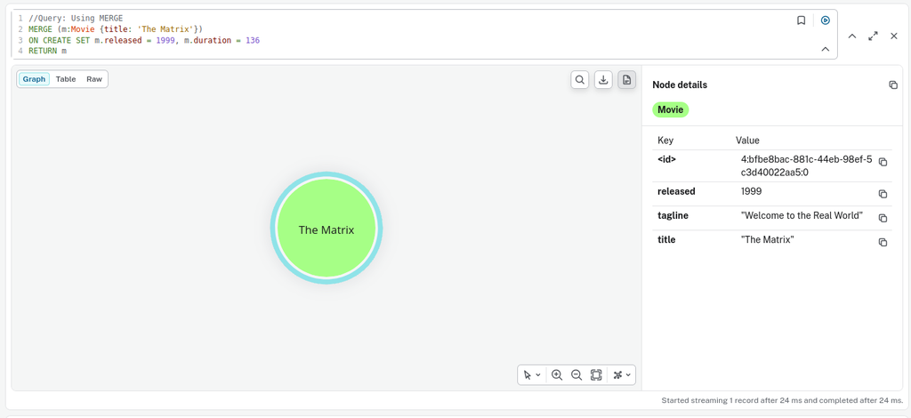

Figure 34: The single `Movie` node returned by the `MERGE`, with the details panel listing `released`, `tagline`, and `title` but no `duration`. The absent property is the evidence that the matching branch was taken and `ON CREATE SET` never ran.

Figure 34 makes the two branches easy to tell apart without reading the status bar. The `tagline` property is the giveaway: nothing in this query mentions it, so it can only have come from the import script, which means the node was matched rather than created. Had `MERGE` created a fresh node, the details panel would show `title`, `released`, and `duration` and no `tagline` at all.

The counterpart is `ON MATCH SET`, which runs only when the pattern was found. The two can be combined in a single statement:

```
MERGE (m:Movie {title: 'The Matrix'})
ON CREATE SET m.released = 1999, m.duration = 136
ON MATCH SET m.duration = 136
RETURN m
```

This form gives an upsert: the node is created with its properties if it is missing, and topped up with the missing `duration` if it is already there.

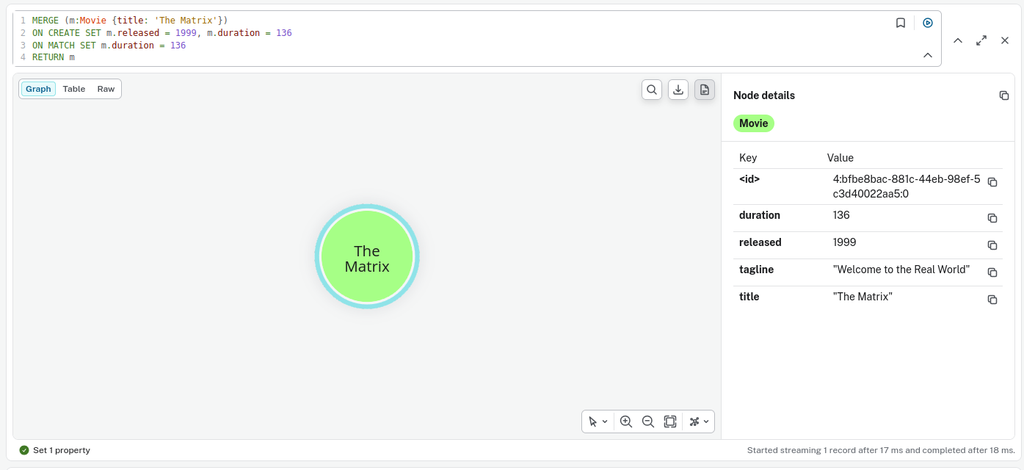

Figure 35: The same node after adding `ON MATCH SET`. `duration` is now present alongside `tagline`, and the status bar reads “Set 1 property”: the matching branch ran and wrote the one property named on it.

Comparing Figure 35 with Figure 34 shows what the second clause changed. The `<id>` is identical in both, so this is the same node being updated in place rather than a duplicate, and `tagline` still confirms that the node came from the import script. What is new is `duration`, written by `ON MATCH SET`, and the status bar’s “Set 1 property” rather than the earlier report of no changes. `ON CREATE SET` still did nothing, which is why only one property was set even though it also names `released`.

**Note**

`ON MATCH SET` overwrites unconditionally, exactly like a plain `SET`. Running this query against a film that already had a different `duration` would replace it silently. Where the intention is to fill gaps rather than overwrite, `ON MATCH SET m.duration = coalesce(m.duration, 136)` keeps any existing value and writes only when the property is missing.

**Warning**

`MERGE` matches on *every* property written inside the pattern. Before the upsert above ran, the node had no `duration`, so `MERGE (m:Movie {title: 'The Matrix', duration: 136})` would have failed to find it and Neo4j would have created a second *The Matrix* instead. Keep the pattern restricted to the identifying properties and push everything else into `ON CREATE SET`.

The uniqueness constraints added in Section 2 matter here for two reasons. They make the match fast, because a constraint creates a supporting index, and they act as a backstop: if a `MERGE` pattern is written too loosely and attempts a duplicate, the constraint rejects the write with an error rather than silently splitting the film into two nodes.

## Merging nodes and relationships together

`MERGE` applies to relationships in exactly the same way, and several `MERGE` clauses can be chained so that each one builds on the variables bound before it:

```
//Query: Using MERGE with Relationships
MERGE (a:Person {name: 'Keanu Reeves'})
MERGE (m:Movie {title: 'The Matrix'})
ON CREATE SET m.released = 1999, m.duration = 136
MERGE (a)-[:ACTED_IN]->(m)
RETURN a, m
```

Each clause is evaluated in order. The first two find the person and the film, the third looks for an `ACTED_IN` edge between the two nodes now bound to `a` and `m`, and because that edge already exists, nothing is written. The `ON CREATE SET` belongs to the `MERGE` immediately above it, not to the statement as a whole, which is why the film’s clause is the only one carrying it.

Note that `RETURN a, m` asks for the two nodes and not the relationship, so the browser draws two unconnected circles for the same reason discussed in Figure 3. Naming the edge, as in `MERGE (a)-[r:ACTED_IN]->(m) RETURN a, r, m`, gives the browser something to draw between them.

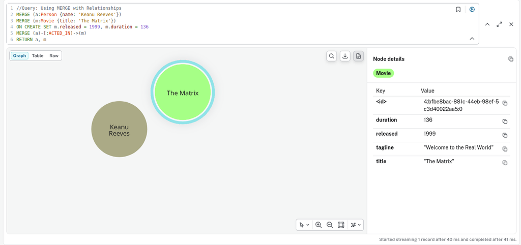

Figure 36: Keanu Reeves and *The Matrix* returned side by side with no arrow between them, even though the `ACTED_IN` relationship exists. The details panel shows the film carrying all four properties, and the status bar reports a read of one record rather than any writes.

Figure 36 confirms that all three `MERGE` clauses matched. The film’s `<id>` is the same one seen in Figure 34 and Figure 35, `duration` is still the 136 written by the previous query rather than something this one set, and the status bar reports no changes at all. The missing arrow is the presentation artefact described above, not a missing edge: the `ACTED_IN` relationship was found by the third `MERGE`, but `RETURN a, m` never asked for it.

**Warning**

When a relationship `MERGE` refers to nodes that are *not* already bound, the whole pattern becomes the search key. `MERGE (a:Person {name: 'Keanu Reeves'})-[:ACTED_IN]->(m:Movie {title: 'The Matrix'})` is safe only because both endpoints exist; had either been missing, Cypher would have created the two nodes *and* the edge rather than reusing what was there. Merging the nodes first and the relationship afterwards, as above, avoids the ambiguity.

## Merging a relationship between nodes found by MATCH

When both endpoints are known to exist, `MATCH` is the clearer way to bind them, leaving `MERGE` responsible for the edge alone:

```
//Query: Using MERGE with Patterns
MATCH (a:Person {name: 'Keanu Reeves'})
MATCH (m:Movie {title: 'The Matrix'})
MERGE (a)-[:ACTED_IN]->(m)
RETURN a, m
```

The difference from the previous query is one of intent rather than result. `MATCH` fails quietly when a node is absent: the pattern produces no rows, so the `MERGE` never runs and nothing is written. `MERGE` on the same pattern would have created the missing node instead. Using `MATCH` for data that must already exist and `MERGE` only for the part that may need creating states that expectation directly, and is the safer default when attaching new relationships to an established graph.

## Running MERGE without a RETURN

A write does not have to hand anything back:

```
//Query: Using MERGE to Avoid Duplicates
MERGE (m:Movie {title: 'The Matrix'})
ON CREATE SET m.released = 1999, m.duration = 136
```

Dropping the `RETURN` leaves a statement whose only purpose is the write, and the status bar rather than the result pane reports what happened. This is the form used throughout the import script in Section 2, and it is what makes the script idempotent: the first run creates each node, and every subsequent run matches it and reports no changes.

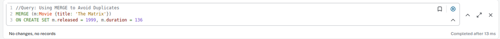

Figure 37: The query with no result pane beneath it, only the status line “No changes, no records”. The absence of a result is the point: the statement was run for its effect on the graph, and there was no effect left to have.

Figure 37 is what idempotence looks like in the browser. “No records” is the consequence of dropping the `RETURN`, and “no changes” is the consequence of the node already existing: the pattern matched, so `ON CREATE SET` was skipped and nothing was written. A first run against an empty database would show “Added 1 label, created 1 node, set 3 properties” instead, and every run after that would return to the line shown here.

## Chaining query parts with WITH

`WITH` ends one part of a query and starts the next, passing on only the variables it names. It was introduced in Section 2 as the bridge that lets a `MATCH` follow a `CREATE`; the same clause chains two reads together:

```
//Query: Using WITH to Chain Queries
MATCH (a:Person{name: 'Keanu Reeves'})-[:ACTED_IN]->(m)
WITH a, m
MATCH (m)<-[r:DIRECTED]-(d:Person)
RETURN a, m, r, d
```

The first `MATCH` produces one row per film Keanu Reeves acted in. `WITH a, m` forwards those two variables, and the second `MATCH` extends each row by finding the people who directed that film. Anything not listed in the `WITH` is dropped at that boundary, which is both a filter on the working set and a guard against accidentally reusing a variable later in the query.

Two details of the pattern are worth noting. The first `MATCH` writes `(m)` with no label, which works because `ACTED_IN` only ever points at a `Movie` in this graph; adding `:Movie` would make the intent explicit and let the planner rule out other labels. The second `MATCH` binds the relationship to `r` and returns it alongside the nodes, which is what allows the browser to draw the edges rather than a set of disconnected circles.

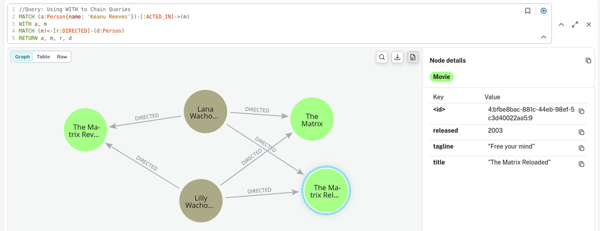

Figure 38: The chained query drawn as a graph, with the Wachowskis in the `Person` colour and the Matrix films in the `Movie` colour, joined by `DIRECTED` edges. The details panel shows the selected node, *The Matrix Reloaded*, carrying the properties the import script wrote.

Figure 38 shows the browser collapsing rows back into a graph. Each returned row is one actor, one film, one `DIRECTED` edge, and one director, but a film directed by both Wachowskis contributes two rows while remaining a single node on screen, which is why three films carry six arrows between them. The visible portion of the result is the Matrix trilogy; panning the canvas reveals the rest of Keanu Reeves’ films and the `Person` node the query started from.

**Warning**

The Movie graph stores the relationship as `(:Person)-[:DIRECTED]->(:Movie)`. If a query `MATCH` is written as `(m)-[:DIRECTED_BY]->(d:Person)`, the query would return no rows at all. Neither a misspelled relationship type nor a reversed arrow raises an error in Cypher. The pattern simply fails to match and the result is empty. The `CALL db.schema.visualization` query shown when the schema was inspected is the quickest way to confirm the type names and directions the data actually uses.

Because the second `MATCH` here is a plain one, a film with no recorded director would drop out of the result entirely, taking the actor row with it. `OPTIONAL MATCH` keeps such rows and fills the missing columns with `null`.

## Aggregating in the middle of a query with WITH

`WITH` also accepts aggregate functions, which is what allows a query to aggregate first and then keep working with the result:

```
//Query: Using WITH for Aggregation
MATCH (a:Person)-[:ACTED_IN]->(m)
WITH a, count(m) as movies
RETURN a.name, movies
ORDER BY movies DESC
```

The grouping rule is the one described in Section 6: `a` is the only non-aggregated expression in the `WITH`, so it becomes the grouping key and `count(m)` is evaluated once per actor. Written this way the counts exist as an ordinary variable for the remainder of the query, so a `WHERE movies > 5` could be added straight after the `WITH` to keep only the prolific actors. That is the Cypher equivalent of SQL’s `HAVING`, and it is the main reason to aggregate in a `WITH` rather than in the `RETURN`.

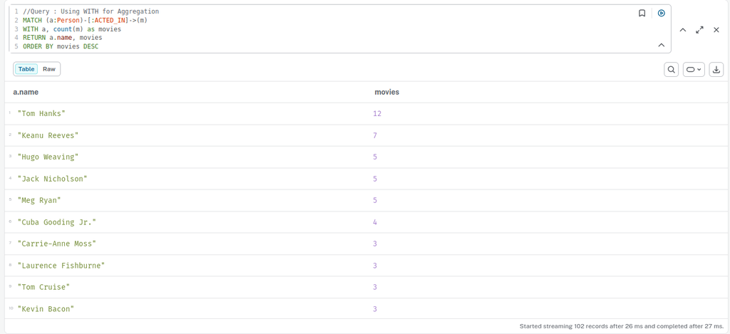

Figure 39: The aggregated result as a table, Tom Hanks on 12 films at the top and the rest of the cast beneath him in descending order. The footer reports 102 records, one per distinct actor rather than one per relationship.

Figure 39 shows the aggregation doing its work. The 172 `ACTED_IN` rows the pattern produced have been reduced to the 102 rows counted in Section 6.2, one for each actor, and the leaderboard at the top is the same one Figure 33 arrived at by a different route: Tom Hanks on 12, Keanu Reeves on 7, then Hugo Weaving, Jack Nicholson, and Meg Ryan level on 5. The column header reads `a.name` rather than `Actor` because this version omits the `AS` alias; adding `RETURN a.name AS Actor, movies` would rename the column without changing a single value.

## Removing duplicate rows with DISTINCT

`RETURN` produces one row per match, not one row per node, so a pattern that matches the same person several times repeats that person in the output:

```
//Query: Using RETURN with DISTINCT
MATCH (a:Person)-[:ACTED_IN]->(m:Movie)
RETURN DISTINCT a.name AS Actor
```

Without `DISTINCT` this query returns 172 rows, one per `ACTED_IN` relationship, with Tom Hanks appearing 12 times. `DISTINCT` deduplicates the rows *after* the projection, leaving the 102 distinct actors counted in Section 6.2. It applies to the whole row rather than to a single column, so adding `m.title` back into the `RETURN` would restore all 172 rows, every one of them already unique.

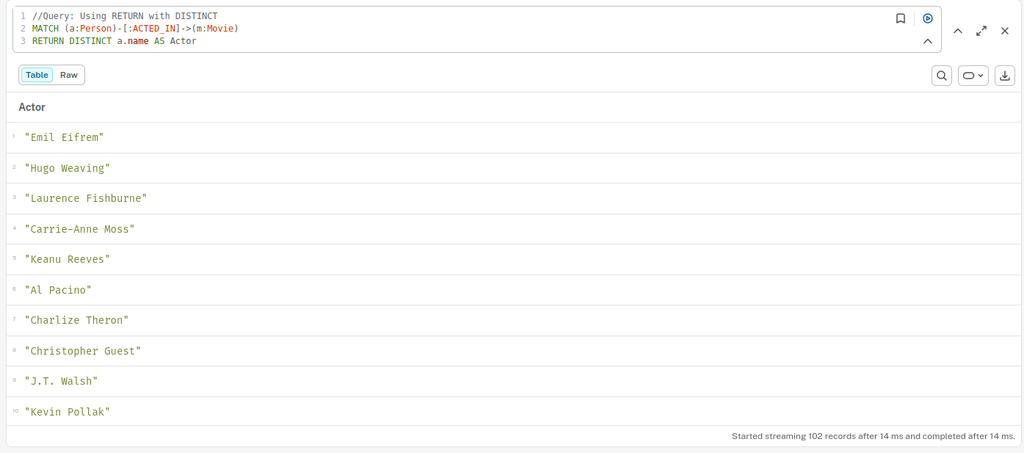

Figure 40: A single `Actor` column with one row per person, beginning with the Matrix cast. The footer reports 102 records, the same total the aggregating query produced, but reached by deduplication rather than by counting.

Figure 40 is the same 102 actors seen in Figure 39, which is the point worth noticing: one query counted the films per actor and the other threw the films away, yet both end with one row per person. The rows are also unordered here, arriving in whatever sequence the pattern matched rather than alphabetically, since no `ORDER BY` was written. The `Actor` header comes from the `AS` alias, and the quotation marks around each value are the browser’s way of marking the column as strings.

**Note**

`RETURN DISTINCT a.name` and `count(DISTINCT a)` deduplicate different things. The first removes duplicate rows from the output; the second removes duplicates inside an aggregate before counting. They agree here only because names happen to be unique in this dataset, and two different actors sharing a name would collapse into one row under `RETURN DISTINCT a.name` while still counting as two under `count(DISTINCT a)`.

## Sorting and truncating the result

`ORDER BY` sorts the rows and `LIMIT` cuts the result short. Neither changes which rows the pattern matched, only how they are presented:

```
//Query: Using RETURN with ORDER BY
MATCH (a:Person)-[:ACTED_IN]->(m:Movie)
RETURN a.name AS Actor, m.title AS Movie
ORDER BY Actor, Movie
```

Listing two expressions sorts on the first and uses the second only to break ties, so the result is grouped by actor with each actor’s films in alphabetical order. Each key can carry its own direction, as in `ORDER BY Actor ASC, Movie DESC`, and `ASC` is the default when nothing is written. Sorting on an alias such as `Actor` works because the alias is defined in the `RETURN` that `ORDER BY` belongs to.

`LIMIT` truncates whatever the preceding clauses produced:

```
//Query: Using RETURN with LIMIT
MATCH (a:Person)-[:ACTED_IN]->(m:Movie)
RETURN a.name AS Actor, m.title AS Movie
LIMIT 5
```

Five rows come back, but *which* five is undefined: with no `ORDER BY` the order is whatever the query planner produced, and it may change between runs or after a write. A bare `LIMIT` is therefore a sampling tool for inspecting the shape of a result, not a way of selecting the top of it. Combining the two clauses, as the leaderboard query in Section 6 does, is what makes the choice deterministic: `ORDER BY` runs first over the complete result and `LIMIT` then keeps the head of the sorted list, which is why `LIMIT 1` after a sort really does return the global maximum.

**Tip**

`SKIP` pairs with `LIMIT` to page through a large result: `ORDER BY Actor SKIP 20 LIMIT 10` returns the third page of ten rows. Paging is only meaningful alongside an `ORDER BY`, since without a stable sort the pages can overlap or miss rows entirely.

# How to find the shortest path between nodes

Every pattern written so far has fixed the number of hops in advance: `(p)-[:ACTED_IN]->(m)` is one hop, and the chained `MATCH` in Section 7 was two. Many interesting questions do not work that way. “How are these two people connected?” has no known length, and the answer is a *path*, a sequence of nodes and relationships joining one end to the other. Cypher can search for the shortest such path directly, which is the graph-database counterpart of the six-degrees-of-separation game and the reason the Movie graph is so often used to demonstrate it.

Two functions do this, and they differ only in how many answers they give back.

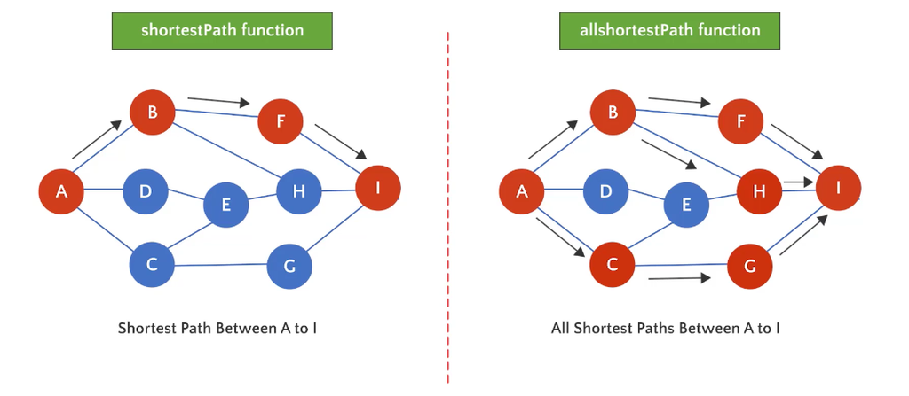

Figure 41: The same question asked twice on a nine-node graph. `shortestPath` returns one three-hop route from A to I, while `allShortestPaths` returns all three routes of that length. Nodes D and E stay unhighlighted in both because no shortest route passes through them.

Figure 41 sets out the distinction before any Cypher is written. Both sides search the same graph and both find routes of the same minimal length, three hops; the left picks one of them and the right returns every one. The longer route A–C–E–H–I exists too, at four hops, but neither function reports it, because both stop as soon as the shortest length has been found. Deciding which of the two to use is therefore a question of whether the alternatives matter: the left is enough to answer “are these connected, and how closely?”, while the right is needed to answer “in how many ways?”.

## Variable-length patterns

The building block is the `*` in a relationship pattern, which turns a fixed hop into a range. `-[*]-` means “one or more relationships of any type, in either direction”, `-[:ACTED_IN*2]-` means exactly two `ACTED_IN` hops, and `-[*1..4]-` bounds the search between one and four. Leaving the arrowhead off makes the pattern undirected, which matters here: an `ACTED_IN` edge points from person to film, so a route between two actors has to travel forwards along one edge and backwards along the next.

The other new piece is naming the path itself. Assigning a pattern to a variable with `path = ...` binds the whole route rather than its endpoints, so `RETURN path` hands the browser every node and relationship along the way.

## Finding one shortest path

`shortestPath()` wraps a variable-length pattern and returns a single shortest route between its two endpoints:

```
//shortestPath function
MATCH (a1:Person {name: 'Keanu Reeves'}), (a2:Person {name: 'Carrie-Anne Moss'})
MATCH path = shortestPath((a1)-[*]-(a2))
RETURN path
```

The first `MATCH` binds the two endpoints, using a comma to separate two independent patterns rather than joining them into one. The comma is important: written as a single pattern the two would have to be connected, whereas here each is matched on its own and both are simply carried into the next clause. The second `MATCH` then searches for the shortest route between the nodes already bound to `a1` and `a2`.

Keanu Reeves and Carrie-Anne Moss are two hops apart, having acted in the same films, so the path returned takes the form `(Keanu)-[:ACTED_IN]->(a film)<-[:ACTED_IN]-(Carrie-Anne Moss)`. Note that the query never mentioned `ACTED_IN`: `[*]` follows whatever relationship types exist, and it is the data rather than the query that decides the route. Restricting the search to `[:ACTED_IN*]` would be both faster and more precise when the question really is about shared films.

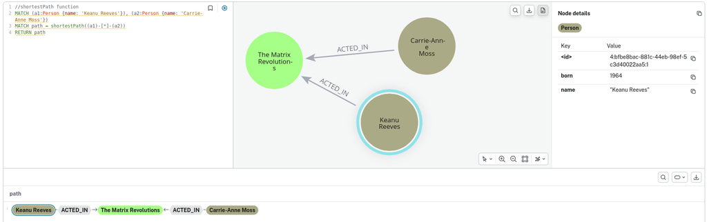

Figure 42: The two-hop route drawn as a graph, with both `Person` nodes pointing at the single `Movie` node between them. The path is also spelled out as a row underneath, `Keanu Reeves -ACTED_IN-> The Matrix Revolutions <-ACTED_IN- Carrie-Anne Moss`.

Figure 42 shows both views of the same result. The graph makes the shape obvious, and the row beneath it is how the browser renders a path value: the nodes and relationships in order, with the arrows drawn in the direction the data stores them rather than the direction the search travelled. Reading it left to right, the route goes forwards out of Keanu Reeves and backwards into Carrie-Anne Moss, which is exactly why the pattern had to be written undirected.

The film in the middle is *The Matrix Revolutions*, which is the first thing to question: the pair also share *The Matrix* and *The Matrix Reloaded*, and either would have been an equally short route. Nothing about the data makes this one preferable; it is simply the one the search happened to return.

`shortestPath()` returns exactly one path even when several are equally short, and gives no indication that the others exist. Which one comes back is not defined, so it should be treated as *a* shortest path rather than *the* shortest path.

## Finding all shortest paths

`allShortestPaths()` takes the same pattern and returns every route of that minimal length:

```
//allShortestPaths function
MATCH (a1:Person {name: 'Keanu Reeves'}), (a2:Person {name: 'Carrie-Anne Moss'})
MATCH path = allShortestPaths((a1)-[*]-(a2))
RETURN path
```

Here the result is three paths rather than one, because the two actors share all three Matrix films and each provides an independent two-hop route. The browser draws them as a single figure with the two `Person` nodes on the outside and the three `Movie` nodes between them, which makes the shape of the connection much clearer than a single path would.

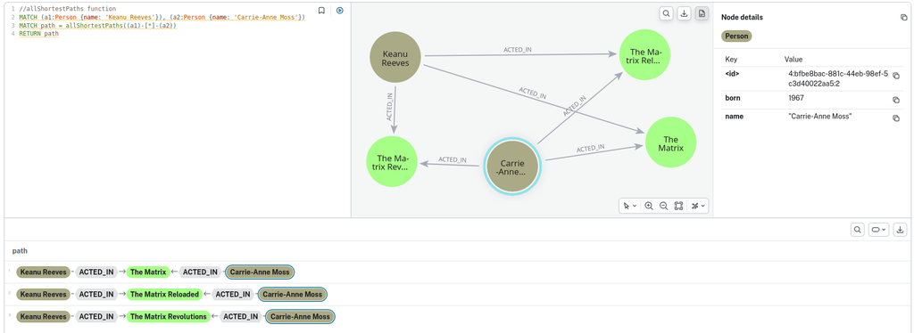

Figure 43: Three paths returned as one drawing: two `Person` nodes, three `Movie` nodes, and six `ACTED_IN` edges. The table underneath lists the routes separately, through *The Matrix*, *The Matrix Reloaded*, and *The Matrix Revolutions*.

Figure 43 puts the arbitrariness of Figure 42 in context. The row that `shortestPath()` returned is the third one here, and the other two were equally valid all along. The graph pane deduplicates shared nodes, so three paths of three nodes each are drawn as five circles rather than nine; the table pane keeps them separate, which is why the two views are worth reading together.

Both functions search only for the *minimum* length. A four-hop connection through a third actor also exists, but neither function will report it while a two-hop route is available; finding those requires a bounded pattern such as `(a1)-[*..4]-(a2)` without the `shortestPath` wrapper, which enumerates every route within the bound instead.

**Warning**

An unbounded `[*]` is only safe inside `shortestPath()` or `allShortestPaths()`, where Neo4j uses a breadth-first search that stops as soon as the target is reached. Writing `MATCH path = (a1)-[*]-(a2)` without the wrapper asks for *every* route between the two nodes, which on a well-connected graph explodes combinatorially and will exhaust memory. Always either wrap the pattern or give the `*` an upper bound.

**Note**

These two functions measure distance in hops, treating every relationship as equally costly. Weighted questions, such as the cheapest route when edges carry a cost, need Dijkstra or A* from the Graph Data Science library rather than the Cypher built-ins shown here.

# Exploring the graph visually with Neo4j Bloom

Every query so far has been written in Cypher and run in the Neo4j Browser, which is the natural tool while learning the language. But a graph is also something to *look at*, and much of the value of one comes from following connections by eye rather than by pattern. **Neo4j Bloom** is the tool built for exactly that: an interactive, visual front end to the same database, designed so that a domain expert who knows nothing about Cypher can still explore the graph, ask questions of it, and share the answers.

Bloom is one of several ways to open a database. In Neo4j Aura, the managed cloud service, the **Open** button on a running instance offers a menu of front ends, and Bloom sits alongside the Browser as a first-class choice.

[figure not shown]

Figure 44: The **Open** menu on a running Aura instance. Alongside *Open with Browser*, the *Open with Bloom* entry launches the visual exploration tool against the same **Movies** database, with *Workspace*, *NEuler*, *NeoDash*, and the command-line *Tools* offered as further front ends.

Figure 44 shows where Bloom is launched from. The database is the one we built earlier, still called **Movies** and marked *Running*; every front end in the menu connects to that same store, so opening it with Bloom shows the identical nodes and relationships the Cypher queries have been returning, only through a different lens.

## What Bloom is for

Bloom’s purpose is to make a graph explorable without writing queries. Where the Browser expects a Cypher statement and answers with whatever that statement returns, Bloom starts from a blank canvas and lets the user build a picture up interactively:

- **Search instead of query.** A single search bar accepts plain phrases such as `Tom Hanks` or `Person ACTED_IN Movie`. Bloom turns the phrase into the underlying Cypher itself, so the user expresses *what* they want to see rather than *how* to retrieve it.
- **Expand by clicking.** Double-clicking a node reveals its neighbours, so a graph can be grown outward one hop at a time, following relationships by eye in the way Section 5 did in Cypher, but without writing a pattern.
- **Perspectives.** A perspective is a saved view of the graph, its labels, the properties shown as captions, and the colours and sizes given to each category, so that a business user opens straight into a meaningful picture rather than a wall of grey circles.
- **Styling that carries meaning.** Node colour, size, and icon can be driven by the data, for example sizing a `Movie` by its number of reviews, turning the visual itself into a form of analysis.
- **Scene sharing.** The resulting view, called a scene, can be saved and shared, which makes Bloom as much a communication tool as an exploration one.

## Exploring without knowing Cypher

The reason Bloom matters for this post is the audience it opens the graph up to. Cypher is expressive, but it is also a language to be learned, and the earlier sections showed how easily a mistyped property name or a back-to-front arrow returns the wrong answer with no error. Bloom removes that barrier by generating the query behind the scenes.

A user who types `Keanu Reeves` into the search bar and double-clicks the node that appears is, in effect, running the `MATCH (p:Person {name: 'Keanu Reeves'})-[r]->(m)` pattern from Section 5, and then following its results outward, without ever seeing the pattern. The search phrase `Person REVIEWED Movie` becomes a relationship query; expanding a film to its cast becomes another. The graph is explored by the same moves a person would make by instinct, click, expand, filter, rearrange, while Bloom translates each move into Cypher underneath.

**Tip**

Bloom is the right tool for exploration and for handing the graph to a non-technical audience; the Browser remains the right tool for precise, repeatable queries and for learning Cypher itself. The two are complementary views of one database, and a common workflow is to discover a pattern visually in Bloom and then formalise it as a Cypher query in the Browser.

**Note**

Because Bloom writes the Cypher for the user, the search phrases it understands depend on the perspective in use: it can only search for the labels, relationship types, and properties that the perspective exposes. A well-configured perspective is therefore what makes the free-text search feel effortless, which is why setting one up is usually the first step when opening a new database in Bloom.

# References

1. Cramlays and Gujral, N. (2026) *Neo4j: Cypher, GDS, GraphQL, LLM, Knowledge Graphs for RAG. Hands-on Course on Neo4j, Cypher, GDS, GraphQL, GraphRAG and Building Knowledge Graph from Unstructured Data Using LLM* [Online course]. Udemy, April 2026. Available at: https://www.udemy.com/course/knowledge-graph-with-neo4j-cypher-gds/.